# Weight lifting performance

Humberto Reyes

April 24, 2015

In this project, the goal is to use data from accelerometers on the belt, forearm, arm, and dumbell of 6 participants. They were asked to perform barbell lifts correctly and incorrectly in 5 different ways. The goal is to predict the manner in which they did the exercise, as classified in the response variable “classe”.

The data for this project come from this source: http://groupware.les.inf.puc-rio.br/har.

### Getting data

```r
setwd("~/courses/autocursos/RCoursera/MachineLearning/project")
#Training data
htp<-"http://d396qusza40orc.cloudfront.net/predmachlearn/pml-training.csv"
##download.file(htp,"raw/training.csv",method="curl")
##Testing data
htp<-"http://d396qusza40orc.cloudfront.net/predmachlearn/pml-testing.csv"
##download.file(htp,"raw/testing.csv",method="curl")
training.raw<-read.csv("raw/training.csv",head=TRUE)
testing<-read.csv("raw/testing.csv",head=TRUE)
```

### Cleaning data

Since there are columns plenty of NAs, I select a training dataframe with no NAs.

```r
#Function to count NAs
countNA<-function(x)sum(is.na(x))
#Training set without columns with NAs
training<-training.raw[,unlist(lapply(training.raw,countNA))==0]
#Select a clean training data set with numerical columns, to pick up variables measured by devices
training<-training[,!unlist(lapply(training,is.factor))]
names(training)
```

```
##  [1] "X"                    "raw_timestamp_part_1" "raw_timestamp_part_2"
##  [4] "num_window"           "roll_belt"            "pitch_belt"
##  [7] "yaw_belt"             "total_accel_belt"     "gyros_belt_x"
## [10] "gyros_belt_y"         "gyros_belt_z"         "accel_belt_x"
## [13] "accel_belt_y"         "accel_belt_z"         "magnet_belt_x"
## [16] "magnet_belt_y"        "magnet_belt_z"        "roll_arm"
## [19] "pitch_arm"            "yaw_arm"              "total_accel_arm"
## [22] "gyros_arm_x"          "gyros_arm_y"          "gyros_arm_z"
## [25] "accel_arm_x"          "accel_arm_y"          "accel_arm_z"
## [28] "magnet_arm_x"         "magnet_arm_y"         "magnet_arm_z"
## [31] "roll_dumbbell"        "pitch_dumbbell"       "yaw_dumbbell"
## [34] "total_accel_dumbbell" "gyros_dumbbell_x"     "gyros_dumbbell_y"
## [37] "gyros_dumbbell_z"     "accel_dumbbell_x"     "accel_dumbbell_y"
## [40] "accel_dumbbell_z"     "magnet_dumbbell_x"    "magnet_dumbbell_y"
## [43] "magnet_dumbbell_z"    "roll_forearm"         "pitch_forearm"
## [46] "yaw_forearm"          "total_accel_forearm"  "gyros_forearm_x"
## [49] "gyros_forearm_y"      "gyros_forearm_z"      "accel_forearm_x"
## [52] "accel_forearm_y"      "accel_forearm_z"      "magnet_forearm_x"
## [55] "magnet_forearm_y"     "magnet_forearm_z"
```

The first four columns should be eliminated. X appears to be an index, whereas raw_timestamp_part_1, raw_timestamp_part_2 and num_window do not appear to be mesurements made by devices

```r
#Remove columns
training<-training[,-c(1:4)]
#Add the classe variable
training<-cbind(training,classe=training.raw$classe)
#Remove raw training data
rm(training.raw)
#Number of columns of the training data set
length(names(training))
```

```
## [1] 53
```

We have 52 numerical features and one categorical response: “classe”

#### Frequencies of classes

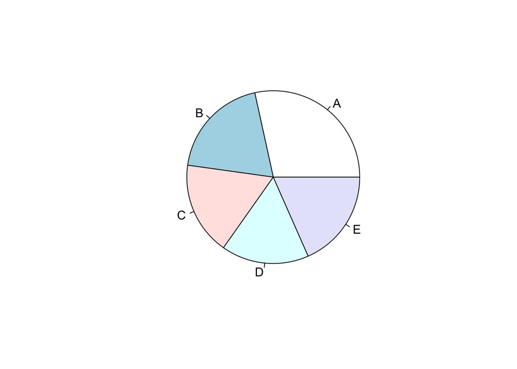

```r
pie(table(training$classe))
```

The frequency of A is slightly higher than those of the remaining classes

Classes represent five different fashions to perform one set of 10 repetitions of the Unilateral Dumbbell Biceps Curl:

Exactly according to the specification (Class A), throwing the elbows to the front (Class B), lifting the dumbbell only halfway (Class C), lowering the dumbbell only halfway (Class D) and throwing the hips to the front (Class E).

### Feature selection

#### Generation of a random set of 1000 records, to pick the most important variables for Random Forest, according to their importance maesured as the mean decrease in the Gini index.

```r
set.seed(123)
#Random subset of 1000 records
inTrain<-sample(dim(training)[1],1000)
#Using the randomForest package
library(randomForest)
#Generatic a random forest object
my.rf1000<-randomForest(classe~.,data=training[inTrain,])
my.rf1000
```

```
##
## Call:
##  randomForest(formula = classe ~ ., data = training[inTrain, ])
##                Type of random forest: classification
##                      Number of trees: 500
## No. of variables tried at each split: 7
##
##         OOB estimate of  error rate: 9.4%
## Confusion matrix:
##     A   B   C   D   E class.error
## A 270   4   2   6   1  0.04593640
## B  13 181  10   3   0  0.12560386
## C   1  10 151   2   1  0.08484848
## D   2   1  16 150   2  0.12280702
## E   0   7  11   2 154  0.11494253
```

```r
#Importance of variables
importance(my.rf1000)
```

```
##                      MeanDecreaseGini
## roll_belt                   50.512358
## pitch_belt                  24.714523
## yaw_belt                    25.513213
## total_accel_belt            12.294062
## gyros_belt_x                 7.763141
## gyros_belt_y                 5.953349
## gyros_belt_z                12.455353
## accel_belt_x                 8.710843
## accel_belt_y                 7.176106
## accel_belt_z                20.165172
## magnet_belt_x               11.763179
## magnet_belt_y               18.773487
## magnet_belt_z               25.615500
## roll_arm                    15.516840
## pitch_arm                    9.844634
## yaw_arm                     10.980668
## total_accel_arm              7.018310
## gyros_arm_x                  9.988978
## gyros_arm_y                  9.887272
## gyros_arm_z                  6.504172
## accel_arm_x                 17.370024
## accel_arm_y                  8.611066
## accel_arm_z                  9.641524
## magnet_arm_x                19.530490
## magnet_arm_y                14.502227
## magnet_arm_z                13.196676
## roll_dumbbell               20.174520
## pitch_dumbbell              14.529657
## yaw_dumbbell                11.881292
## total_accel_dumbbell        13.418144
## gyros_dumbbell_x             9.713463
## gyros_dumbbell_y            13.114727
## gyros_dumbbell_z             8.384287
## accel_dumbbell_x            15.159159
## accel_dumbbell_y            21.874643
## accel_dumbbell_z            12.932270
## magnet_dumbbell_x           21.130864
## magnet_dumbbell_y           29.833281
## magnet_dumbbell_z           32.310240
## roll_forearm                20.978817
## pitch_forearm               36.048799
## yaw_forearm                  7.335311
## total_accel_forearm          8.900288
## gyros_forearm_x              7.090831
## gyros_forearm_y             10.205978
## gyros_forearm_z              8.121658
## accel_forearm_x             18.285403
## accel_forearm_y             10.350449
## accel_forearm_z             12.532613
## magnet_forearm_x            13.329953
## magnet_forearm_y            13.554660
## magnet_forearm_z            14.604171
```

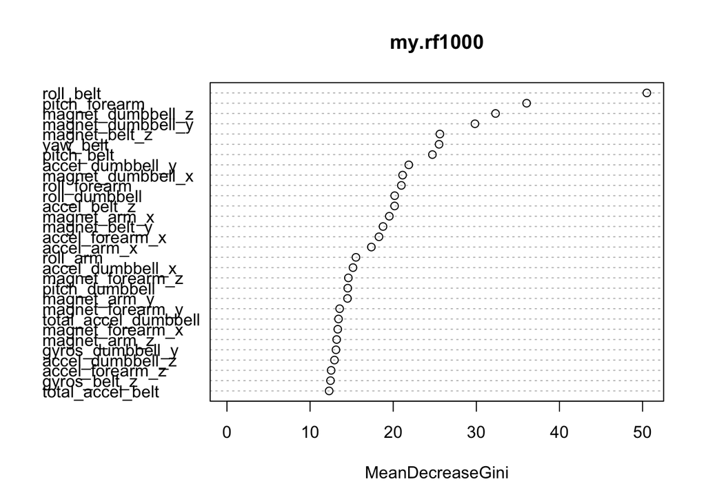

```r
#Plot of importances
varImpPlot(my.rf1000)
```

Near the value of 17, there is a trend of faster increase in importance.

#### Chosing features with importance greater than 17

```r
#Training data with selected features
redTrain<-training[,importance(my.rf1000)[,1]>17]
names(redTrain)
```

```
##  [1] "roll_belt"         "pitch_belt"        "yaw_belt"
##  [4] "accel_belt_z"      "magnet_belt_y"     "magnet_belt_z"
##  [7] "accel_arm_x"       "magnet_arm_x"      "roll_dumbbell"
## [10] "accel_dumbbell_y"  "magnet_dumbbell_x" "magnet_dumbbell_y"
## [13] "magnet_dumbbell_z" "roll_forearm"      "pitch_forearm"
## [16] "accel_forearm_x"   "classe"
```

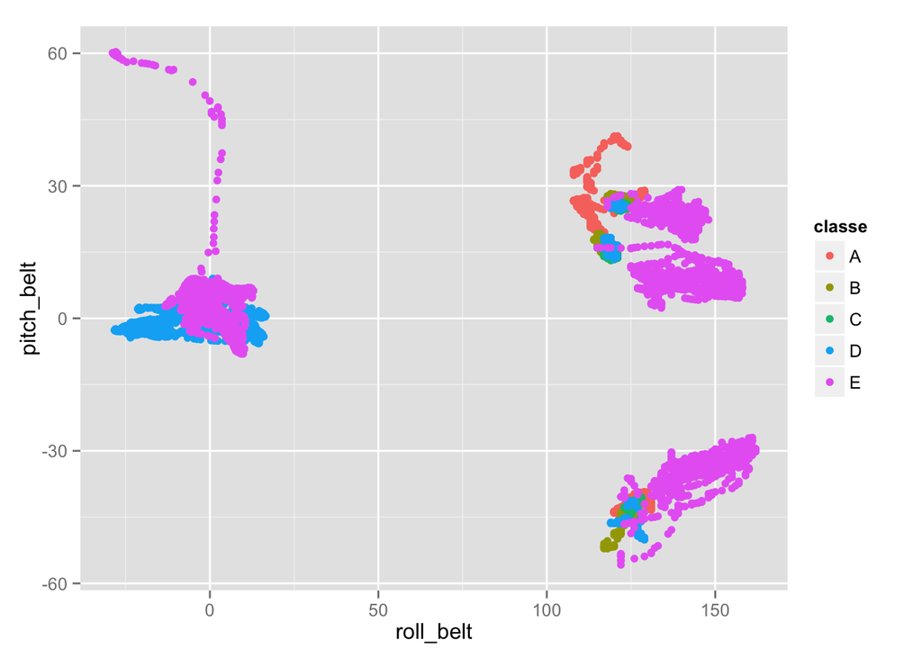

```r
library(ggplot2)
qplot(roll_belt,pitch_belt,data=redTrain,colour=classe)
```

However, as we can see, they cannot unambiguously classify by themeselves “classe”

### Random Forest with all records for selected features

```r
set.seed(123)
my.rfAll<-randomForest(classe~.,data=redTrain)
my.rfAll
```

```
##
## Call:
##  randomForest(formula = classe ~ ., data = redTrain)
##                Type of random forest: classification
##                      Number of trees: 500
## No. of variables tried at each split: 4
##
##         OOB estimate of  error rate: 0.56%
## Confusion matrix:
##      A    B    C    D    E  class.error
## A 5575    4    1    0    0 0.0008960573
## B   14 3752   29    2    0 0.0118514617
## C    0   14 3403    5    0 0.0055523086
## D    0    0   22 3192    2 0.0074626866
## E    0    2    4   10 3591 0.0044358192
```

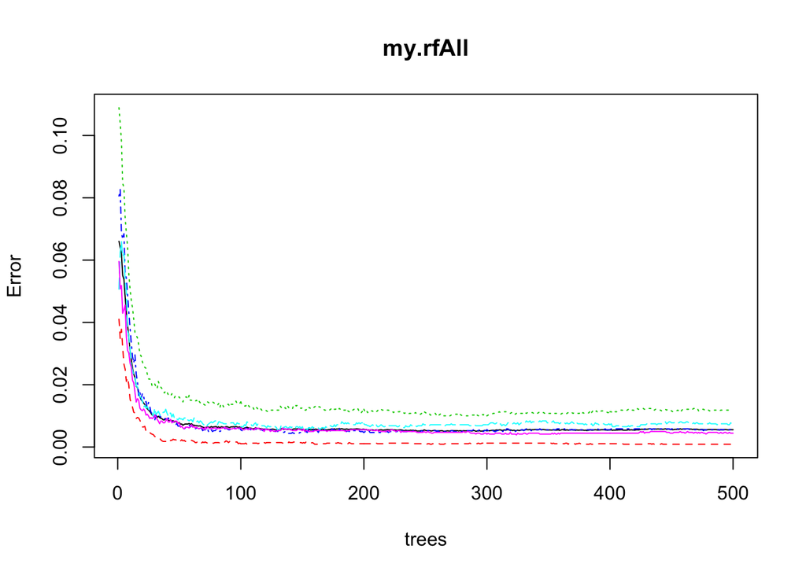

```r
#Plot of errors accross the number of trees
plot(my.rfAll)
```

The Out of Bag Error is 0.56%, which gives an accuracy of 99.44%

### Cross validation by 5-fold

This cross validations, besides indicating the out of sample error with the selected 16 features, indicates how error changes by eliminating predictors.

```r
set.seed(123)
obj<-rfcv(redTrain[,-c(17)],redTrain[,c(17)]) #cross-validation in randomForest package
#Numbers of features
obj$n.var
```

```
## [1] 16  8  4  2  1
```

```r
#Cross-validation error
obj$error.cv
```

```
##          16           8           4           2           1
## 0.006421364 0.012180206 0.052899806 0.374426664 0.589644277
```

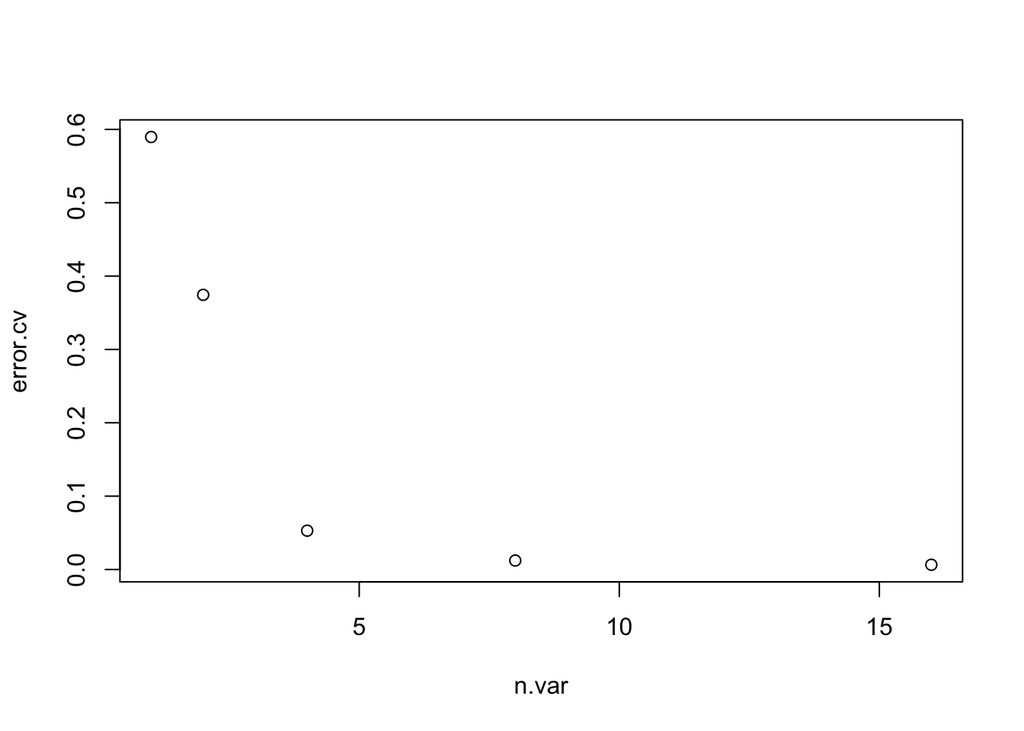

```r
#Graphical representation of cross-validation errors against number of features
with(obj, plot(n.var, error.cv))
```

The cross-validation error = 0.0064214 is not far from the Out of Bag Error calculated by randomForest of 0.56%, i.e., 0.0056. The accuracy according to cross-validation is 99.36%.

### Prediction for the test set

```r
predict(my.rfAll,testing)
```

```
##  1  2  3  4  5  6  7  8  9 10 11 12 13 14 15 16 17 18 19 20
##  B  A  B  A  A  E  D  B  A  A  B  C  B  A  E  E  A  B  B  B
## Levels: A B C D E
```

The probability of correctly predicting the 20 cases is:

```r
dbinom(20,20,(1-obj$error.cv[1]))
```

```
## [1] 0.8791134
```

… and it did : )